# Data analysis with mixed-effect models: sensitivity to phonological patterns in auditory language processing

Yiling Huo

2022-03-07

In this experiment, participants heard words and phrases in Mandarin Chinese that either violated a phonological rule (tone sandhi) or did not violate the rule. Participants were prompted to rate the acceptability of the spoken phrase.

There were two types of trials corresponding to two different tone sandhi rules, corresponding to two word (both numerals) in which a tone sandhi can apply: *yi* trials, and *liang* trials.

I included three fixed factors in the model: critical word (*yi* vs. *liang*), condition (violation/mismatch vs. no violation/match), and phonological context (sandhi inducing vs. non-sandhi inducing). I used visualisation to help me select an appropriate random effect structure, before deciding to include by-participant and by-item random intercepts.

The results suggested a three-way interaction, which I followed up with pairwise comparisons, revealing that listeners were overall highly sensitive to phonological pattern violations, but this sensitivity was reduced for *liang* in the sandhi-inducing context.

# 1 Prepare environment

```r
# clear workspace
rm(list = ls())

library(readr)
library(lme4)
library(languageR)
library(ggplot2)
library(dplyr)
library(ggpubr)
library(sjPlot)
library(Matrix)
library(car)
library(stats)
library(cAIC4)
library(emmeans)
library(effects)

# Set working directory if necessary
#InDir = ""
#setwd(InDir)
```

# 2 Prepare data set

## 2.1 Load files

```r
# file name of data sets
questionnaire_1_name <- 'data_exp_77988-v3_questionnaire-y3gp.csv'
questionnaire_2_name <- 'data_exp_77988-v3_questionnaire-k3ph.csv'
list_1_name <- 'data_exp_77988-v3_task-d37t.csv'
list_2_name <- 'data_exp_77988-v3_task-5hmx.csv'
list_3_name <- 'data_exp_77988-v3_task-84us.csv'
list_4_name <- 'data_exp_77988-v3_task-qqae.csv'

# old_data <- 'data_ready_old.csv'

# beginning questionnaire
ques_1 <- read.csv(questionnaire_1_name,header = TRUE)
ques_1 <- select(ques_1, c(Participant.Public.ID, participant.ID, list))
ques_1 <- droplevels(subset(ques_1, Participant.Public.ID != ''))
names(ques_1)[names(ques_1) == "list"] <- "eyetracking_list"

# end questionnaire
ques_2 <- read.csv(questionnaire_2_name, header = TRUE)
ques_2 <- select(ques_2, c(Participant.Public.ID, yi_classroom.quantised, yi_awareness.quantised, third_classroom.quantised, third_awareness.quantised))
ques_2 <- droplevels(subset(ques_2, Participant.Public.ID != ''))

# list 1
list_1 <- readr::read_csv(list_1_name, name_repair = make.names)
# get rid of unnecessary columns and rows
list_1 <- select(list_1, -c(Event.Index, UTC.Timestamp, UTC.Date, Local.Timestamp, Local.Timezone, Local.Date, Experiment.ID, Experiment.Version, Tree.Node.Key, Repeat.Key, Schedule.ID, Participant.Private.ID, Participant.Starting.Group, Participant.Status, Participant.Completion.Code, Participant.External.Session.ID, randomiser.sjj5, Participant.Device.Type, Participant.Device, Participant.OS, Participant.Browser, Participant.Monitor.Size, Participant.Viewport.Size, Checkpoint, Task.Name, Task.Version, Spreadsheet, Spreadsheet.Name, Spreadsheet.Row, Trial.Number, Screen.Number, Screen.Name, Zone.Name, Zone.Type, Reaction.Time, Reaction.Onset, Response.Type, Attempt, Correct, Incorrect, Dishonest, X.Coordinate, Y.Coordinate, Timed.Out, randomise_blocks, randomise_trials, ANSWER, audio, Audio))
list_1 <- droplevels(subset(list_1, Response != "N/A" & display != "Practice"))

# List 2
list_2 <- readr::read_csv(list_2_name, name_repair = make.names)
list_2 <- select(list_2, -c(Event.Index, UTC.Timestamp, UTC.Date, Local.Timestamp, Local.Timezone, Local.Date, Experiment.ID, Experiment.Version, Tree.Node.Key, Repeat.Key, Schedule.ID, Participant.Private.ID, Participant.Starting.Group, Participant.Status, Participant.Completion.Code, Participant.External.Session.ID, randomiser.sjj5, Participant.Device.Type, Participant.Device, Participant.OS, Participant.Browser, Participant.Monitor.Size, Participant.Viewport.Size, Checkpoint, Task.Name, Task.Version, Spreadsheet, Spreadsheet.Name, Spreadsheet.Row, Trial.Number, Screen.Number, Screen.Name, Zone.Name, Zone.Type, Reaction.Time, Reaction.Onset, Response.Type, Attempt, Correct, Incorrect, Dishonest, X.Coordinate, Y.Coordinate, Timed.Out, randomise_blocks, randomise_trials, ANSWER, audio, Audio))
list_2 <- droplevels(subset(list_2, Response != "N/A" & display != "Practice"))

# List 3
list_3 <- readr::read_csv(list_3_name, name_repair = make.names)
list_3 <- select(list_3, -c(Event.Index, UTC.Timestamp, UTC.Date, Local.Timestamp, Local.Timezone, Local.Date, Experiment.ID, Experiment.Version, Tree.Node.Key, Repeat.Key, Schedule.ID, Participant.Private.ID, Participant.Starting.Group, Participant.Status, Participant.Completion.Code, Participant.External.Session.ID, randomiser.sjj5, Participant.Device.Type, Participant.Device, Participant.OS, Participant.Browser, Participant.Monitor.Size, Participant.Viewport.Size, Checkpoint, Task.Name, Task.Version, Spreadsheet, Spreadsheet.Name, Spreadsheet.Row, Trial.Number, Screen.Number, Screen.Name, Zone.Name, Zone.Type, Reaction.Time, Reaction.Onset, Response.Type, Attempt, Correct, Incorrect, Dishonest, X.Coordinate, Y.Coordinate, Timed.Out, randomise_blocks, randomise_trials, ANSWER, audio, Audio))
list_3 <- droplevels(subset(list_3, Response != "N/A" & display != "Practice"))

# List 4
list_4 <- readr::read_csv(list_4_name, name_repair = make.names)
list_4 <- select(list_4, -c(Event.Index, UTC.Timestamp, UTC.Date, Local.Timestamp, Local.Timezone, Local.Date, Experiment.ID, Experiment.Version, Tree.Node.Key, Repeat.Key, Schedule.ID, Participant.Private.ID, Participant.Starting.Group, Participant.Status, Participant.Completion.Code, Participant.External.Session.ID, randomiser.sjj5, Participant.Device.Type, Participant.Device, Participant.OS, Participant.Browser, Participant.Monitor.Size, Participant.Viewport.Size, Checkpoint, Task.Name, Task.Version, Spreadsheet, Spreadsheet.Name, Spreadsheet.Row, Trial.Number, Screen.Number, Screen.Name, Zone.Name, Zone.Type, Reaction.Time, Reaction.Onset, Response.Type, Attempt, Correct, Incorrect, Dishonest, X.Coordinate, Y.Coordinate, Timed.Out, randomise_blocks, randomise_trials, ANSWER, audio, Audio))
list_4 <- droplevels(subset(list_4, Response != "N/A" & display != "Practice"))

# old data from 2019
data_ready_old <- readr::read_csv('data_ready_2019.csv')
data_ready_old <- data_ready_old %>%
  select(-c(...1))
```

## 2.2 Prepare dataset

```r
# combine all four lists
exp_data <- rbind(list_1, list_2, list_3, list_4)
# set as factors for the merge function
exp_data$Participant.Public.ID <- as.factor(exp_data$Participant.Public.ID)
ques_1$Participant.Public.ID <- as.factor(ques_1$Participant.Public.ID)
ques_2$Participant.Public.ID <- as.factor(ques_2$Participant.Public.ID)
# merge two questionnaires
ques <- merge(ques_1, ques_2, by = 'Participant.Public.ID' )
# merge questionnaire with data (add questionnaire answer to each row)
data_ready_new <- merge(exp_data, ques,by = 'Participant.Public.ID')

# mutate participant id to 22xxx
for(i in 1:nrow(data_ready_new)){
  pubid <- data_ready_new$Participant.Public.ID[i]
  id <- data_ready_new$participant.ID[i]
  if(id < 10) {
    if(pubid == '5mor1gnb'){
      data_ready_new$subject[i] <- paste('2200', data_ready_new$participant.ID[i], sep = '')
    } else {
      data_ready_new$subject[i] <- paste('220', data_ready_new$participant.ID[i], sep = '')
    }
  } else {
    data_ready_new$subject[i] <- paste('22', data_ready_new$participant.ID[i], sep = '')
  }
}

# change some of the column names
names(data_ready_new)[names(data_ready_new) == "subject"] <- "ParticipantID"
names(data_ready_new)[names(data_ready_new) == "yi_classroom.quantised"] <- "yi_classroom"
names(data_ready_new)[names(data_ready_new) == "yi_awareness.quantised"] <- "yi_awareness"
names(data_ready_new)[names(data_ready_new) == "third_classroom.quantised"] <- "third_classroom"
names(data_ready_new)[names(data_ready_new) == "third_awareness.quantised"] <- "third_awareness"
names(data_ready_new)[names(data_ready_new) == "match.mismatch"] <- "match"

names(data_ready_old)[names(data_ready_old) == "match/mismatch"] <- "match"

# combine old data and new data
data_ready <- plyr::rbind.fill(data_ready_new, data_ready_old)
# or just analyse old or new data
data_ready <- data_ready_new
#data_ready <- data_ready_old

# set independent variables as factors
data_ready$numeral <- as.factor(data_ready$numeral)
data_ready$match <- as.factor(data_ready$match)
data_ready$sandhi_inducing <- as.factor(data_ready$sandhi_inducing)
raw_data <- data_ready

# exclude pilot participant
raw_data <- droplevels(subset(raw_data, ParticipantID != 22001))
```

# 3 Analysis

## 3.1 Prepare dataset for models

```r
###z-transform the data, creates a new column 'z'
raw_data$z <- ave(raw_data$Response, raw_data$ParticipantID, FUN= scale)

# select experimental conditions
yi_liang <- droplevels(subset(raw_data, condition %in% c('a','b','c','d')))

# code the parameters, use sum coding (factors add to zero)
contrasts(yi_liang$numeral) <- contr.sum(2)
contrasts(yi_liang$numeral)
```

```
##       [,1]
## liang    1
## yi      -1
```

```r
contrasts(yi_liang$match) <- contr.sum(2)
contrasts(yi_liang$match)
```

```
##   [,1]
## n    1
## y   -1
```

```r
contrasts(yi_liang$sandhi_inducing) <- contr.sum(2)
contrasts(yi_liang$sandhi_inducing)
```

```
##   [,1]
## n    1
## y   -1
```

```r
# replace conditions 'a,b,c,d' with condition names such as 'yi_match, yi_mismatch,...'
yi_liang$condition <- ifelse(yi_liang$condition=='a', 'yi_match', ifelse(yi_liang$condition=='b','yi_mismatch', ifelse(yi_liang$condition=='c','liang_match','liang_mismatch')))

# random factors
yi_liang$ParticipantID <- as.factor(yi_liang$ParticipantID)
yi_liang$item <- as.factor(yi_liang$item)

# summary of data set
summary(yi_liang)
```

```
##  Participant.Public.ID    Response      display              word
##  1339tnn1:  48         Min.   :1.00   Length:2064        Length:2064
##  1wbu7xv2:  48         1st Qu.:1.00   Class :character   Class :character
##  254x0di5:  48         Median :7.00   Mode  :character   Mode  :character
##  3oorci1k:  48         Mean   :4.61
##  5o8capyn:  48         3rd Qu.:7.00
##  65j4upra:  48         Max.   :7.00
##  (Other) :1776
##   audio_file           pinyin               list            no.
##  Length:2064        Length:2064        Min.   :1.000   Min.   :  3.00
##  Class :character   Class :character   1st Qu.:1.000   1st Qu.: 31.00
##  Mode  :character   Mode  :character   Median :2.000   Median : 60.00
##                                        Mean   :2.488   Mean   : 60.04
##                                        3rd Qu.:4.000   3rd Qu.: 89.00
##                                        Max.   :4.000   Max.   :120.00
##
##    trial_id             type                item       condition
##  Length:2064        Length:2064        1      :  43   Length:2064
##  Class :character   Class :character   10     :  43   Class :character
##  Mode  :character   Mode  :character   11     :  43   Mode  :character
##                                        12     :  43
##                                        13     :  43
##                                        14     :  43
##                                        (Other):1806
##  sandhi_inducing  numeral     match    numeral_tone          cl_tone
##  n:1032          liang:1032   n:1032   Length:2064        Min.   :3.0
##  y:1032          yi   :1032   y:1032   Class :character   1st Qu.:3.0
##                                        Mode  :character   Median :3.5
##                                                           Mean   :3.5
##                                                           3rd Qu.:4.0
##                                                           Max.   :4.0
##
##       cl            participant.ID  eyetracking_list  yi_classroom
##  Length:2064        Min.   : 1.00   Min.   :1.000    Min.   :1.000
##  Class :character   1st Qu.:12.00   1st Qu.:2.000    1st Qu.:1.000
##  Mode  :character   Median :23.00   Median :3.000    Median :2.000
##                     Mean   :22.84   Mean   :2.535    Mean   :1.907
##                     3rd Qu.:34.00   3rd Qu.:4.000    3rd Qu.:3.000
##                     Max.   :44.00   Max.   :4.000    Max.   :3.000
##
##   yi_awareness   third_classroom third_awareness ParticipantID
##  Min.   :1.000   Min.   :1.000   Min.   :1.000   2201   :  48
##  1st Qu.:1.000   1st Qu.:1.000   1st Qu.:1.000   2202   :  48
##  Median :1.000   Median :2.000   Median :1.000   2203   :  48
##  Mean   :1.279   Mean   :1.744   Mean   :1.302   2204   :  48
##  3rd Qu.:2.000   3rd Qu.:2.000   3rd Qu.:2.000   2205   :  48
##  Max.   :2.000   Max.   :3.000   Max.   :2.000   2206   :  48
##                                                  (Other):1776
##        z
##  Min.   :-1.98426
##  1st Qu.:-1.24112
##  Median : 0.65155
##  Mean   :-0.04396
##  3rd Qu.: 0.83351
##  Max.   : 1.13165
##
```

## 3.2 Visualise the data

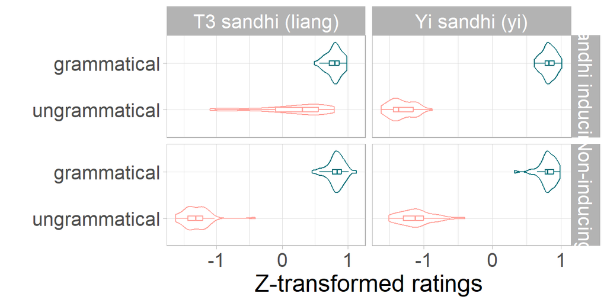

```r
# violin plots
# aggregate data frame to plot by subject data
agg <- aggregate(z ~ ParticipantID + sandhi_inducing + numeral + match + condition, yi_liang, mean)
agg$xlab <- paste(agg$condition,agg$sandhi_inducing)

#nicer order of conditions
agg$sandhi_inducing <- factor(agg$sandhi_inducing, levels = c("y","n"))
agg$numeral <- factor(agg$numeral, levels = c('liang', 'yi'))
agg$xlab <- factor(agg$xlab, levels = c("yi_match y","yi_mismatch y","liang_match y","liang_mismatch y",
                                        "yi_match n","yi_mismatch n","liang_match n","liang_mismatch n"))
agg$match <- factor(agg$match, levels = c('y', 'n'))

#nicer labels
cond_labs_sandhi <- c("Sandhi inducing","Non-inducing")
names(cond_labs_sandhi) <- c("y","n")

cond_labs_condition <- c("yi match","yi mismatch","liang match","liang mismatch")
names(cond_labs_condition) <- c("yi_match","yi_mismatch","liang_match","liang_mismatch")

cond_labs_xlab <- c("yi match\n(yi2 ge4)","yi mismatch\n(yi4 ge4)","liang match\n(liang2 ben3)","liang mismatch\n(liang3 ben3)",
                    "yi match\n(yi4 ben3)","yi mismatch\n(yi2 ben3)","liang match\n(liang3 ge4)","liang mismatch\n(liang2 ge4)")
names(cond_labs_xlab) <- c("yi_match y","yi_mismatch y","liang_match y","liang_mismatch y",
                           "yi_match n","yi_mismatch n","liang_match n","liang_mismatch n")

agg$match <- ifelse(agg$match == 'y', 'grammatical', 'ungrammatical')
agg$match <- factor(agg$match, levels=c('ungrammatical', 'grammatical'))

mat_labs_condition <- c('grammatical', 'ungrammatical')
names(mat_labs_condition) <- c('match', 'mismatch')
num_labs_condition <- c("Yi sandhi (yi)","T3 sandhi (liang)")
names(num_labs_condition) <- c('yi', 'liang')

# plot
violin_plot <- ggplot(agg, aes(x=match, y=z, color=match)) + geom_violin() +
  facet_grid(sandhi_inducing~numeral,scales = 'free',
             labeller = labeller(sandhi_inducing = cond_labs_sandhi, numeral=num_labs_condition)) +
  geom_boxplot(outlier.shape = NA, lwd = 0.5, fatten = 1.2, width = 0.1) +
  coord_flip() + theme_light() +
  ylab("Z-transformed ratings") + xlab("") +
  scale_color_manual(values=c("#FFA29B","#006f78")) +
  theme(text=element_text(size=20),
        legend.position = 'none')
        #strip.background = element_rect(fill="#BBC592"),
        #panel.grid = element_line(colour = "#e4e8d1"),
        #panel.border = element_rect(colour = "#e4e8d1"),
        #axis.ticks = element_line(colour = "#e4e8d1"),
        #axis.text = element_text(colour = "#2a350c"))
violin_plot
```

```r
#write pdf 1:2, width/height in inches
# pdf("task_3_vplot.pdf", width = 8, height = 4.5)
# print(violin_plot)
# dev.off()
```

## 3.3 Mixed-effect models

### 3.3.1 Explore appropriate random effect structures

The size of this dataset does not support the maximal random effect structure. Here I use by-participant and by-item visualisations to help me select appropriate random effect structure.

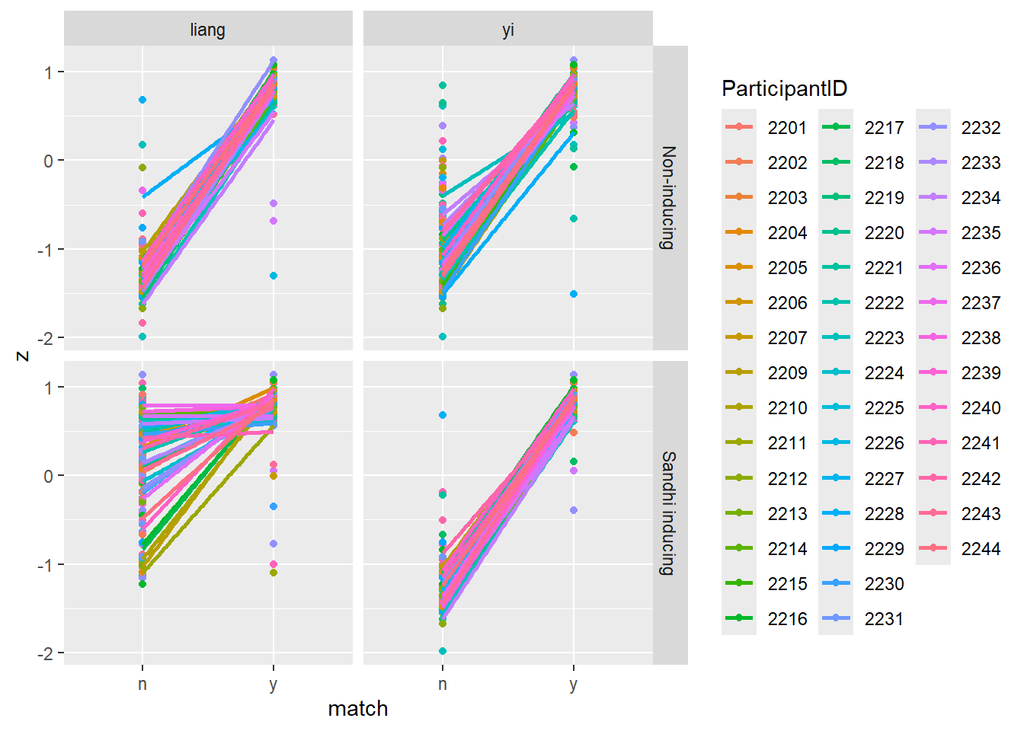

```r
# model with maximal random effects does not converge
#mixed_effects_max <- lmer(z ~ match*sandhi_inducing*numeral + (0+match * sandhi_inducing * numeral||ParticipantID) + (0+match * sandhi_inducing * numeral||item), data = yi_liang,REML = FALSE, verbose = 2,  control = lmerControl(optimizer = 'bobyqa'))

# by-participant plot to help select random effects
ggplot(yi_liang, aes(y = z, x = match, colour = ParticipantID, group = ParticipantID)) + geom_point() + geom_smooth(method = "lm", se = FALSE) + facet_grid(sandhi_inducing~numeral, scales = 'free', labeller = labeller(sandhi_inducing = cond_labs_sandhi))
```

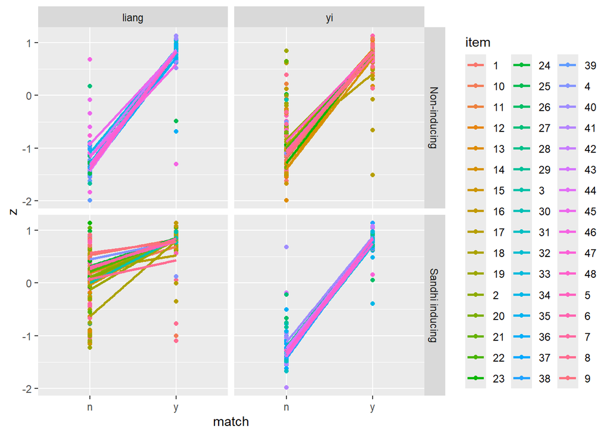

```r
# by-item plot to help select random effects
ggplot(yi_liang, aes(y = z, x = match, colour = item, group = item)) + geom_point() + geom_smooth(method = "lm", se = FALSE) + facet_grid(sandhi_inducing~numeral, scales = 'free', labeller = labeller(sandhi_inducing = cond_labs_sandhi))
```

### 3.3.2 Run model

```r
#simpler model with only random intercepts
mixed_effects <- lmer(z ~ match*sandhi_inducing*numeral + (1|ParticipantID) + (1|item), data = yi_liang,REML = FALSE)

# see how the variances are explained by random effects
summary(rePCA(mixed_effects))
```

```
## $item
## Importance of components:
##                           [,1]
## Standard deviation     0.05654
## Proportion of Variance 1.00000
## Cumulative Proportion  1.00000
##
## $ParticipantID
## Importance of components:
##                           [,1]
## Standard deviation     0.05977
## Proportion of Variance 1.00000
## Cumulative Proportion  1.00000
```

```r
# see if model suffers from singular fit
isSingular(mixed_effects)
```

```
## [1] FALSE
```

```r
summary(mixed_effects)
```

```
## Linear mixed model fit by maximum likelihood  ['lmerMod']
## Formula: z ~ match * sandhi_inducing * numeral + (1 | ParticipantID) +
##     (1 | item)
##    Data: yi_liang
##
##       AIC       BIC    logLik -2*log(L)  df.resid
##    1668.9    1730.9    -823.5    1646.9      2053
##
## Scaled residuals:
##     Min      1Q  Median      3Q     Max
## -6.4101 -0.3467 -0.0056  0.3471  5.5439
##
## Random effects:
##  Groups        Name        Variance  Std.Dev.
##  item          (Intercept) 0.0004131 0.02032
##  ParticipantID (Intercept) 0.0004617 0.02149
##  Residual                  0.1292218 0.35947
## Number of obs: 2064, groups:  item, 48; ParticipantID, 43
##
## Fixed effects:
##                                   Estimate Std. Error  t value
## (Intercept)                      -0.043959   0.009053   -4.856
## match1                           -0.851483   0.007913 -107.609
## sandhi_inducing1                 -0.156396   0.007913  -19.765
## numeral1                          0.159405   0.007913   20.145
## match1:sandhi_inducing1          -0.158945   0.007913  -20.087
## match1:numeral1                   0.162165   0.007913   20.494
## sandhi_inducing1:numeral1        -0.203422   0.008439  -24.106
## match1:sandhi_inducing1:numeral1 -0.214850   0.007913  -27.152
##
## Correlation of Fixed Effects:
##             (Intr) match1 sndh_1 numrl1 mt1:_1 mtc1:1 sn_1:1
## match1      0.000
## sndh_ndcng1 0.000  0.000
## numeral1    0.000  0.000  0.000
## mtch1:snd_1 0.000  0.000  0.000  0.000
## mtch1:nmrl1 0.000  0.000  0.000  0.000  0.000
## sndh_ndc1:1 0.000  0.000  0.000  0.000  0.000  0.000
## mtch1:s_1:1 0.000  0.000  0.000  0.000  0.000  0.000  0.000
```

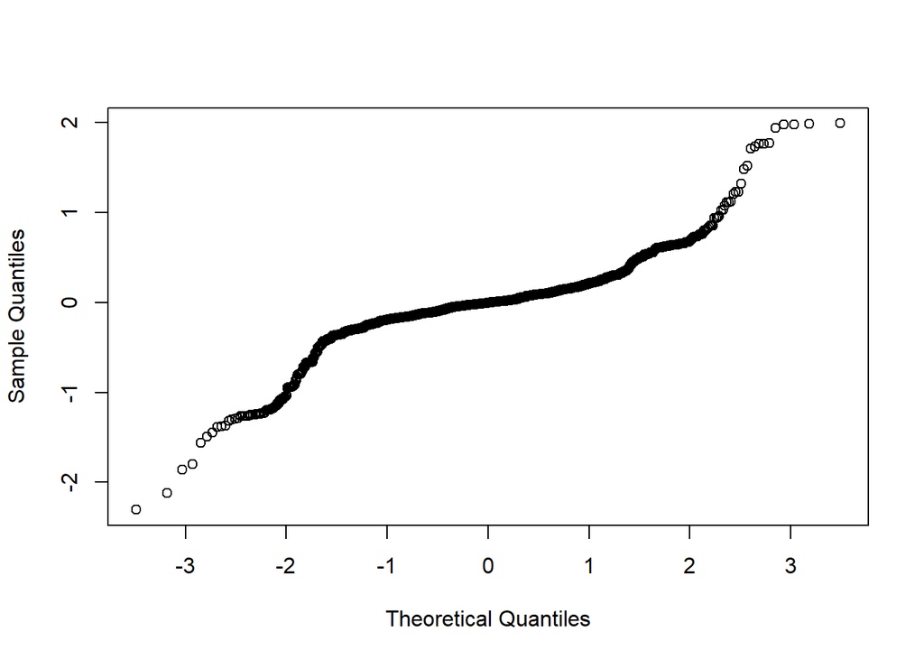

```r
#diagnostic plots
qqnorm(residuals(mixed_effects),main="")
```

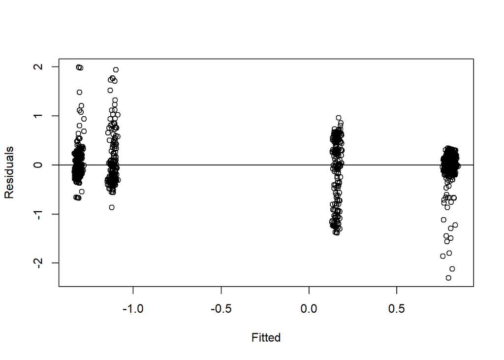

```r
plot(fitted(mixed_effects),residuals(mixed_effects),xlab="Fitted",ylab="Residuals")
abline(h=0)
```

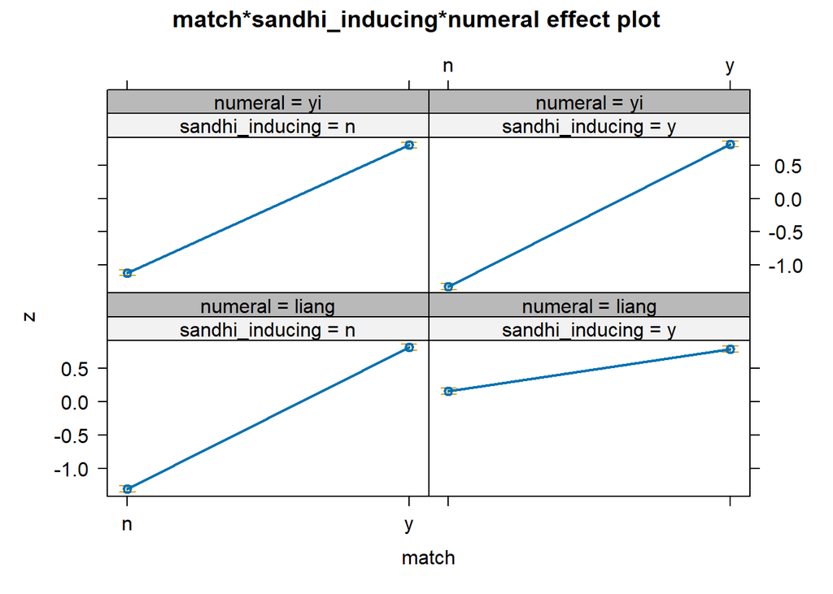

```r
# effects (to explore interaction)
plot(allEffects(mixed_effects))
```

```r
emmeans(mixed_effects, pairwise ~ numeral*match)$contrasts
```

```
## NOTE: Results may be misleading due to involvement in interactions
```

```
##  contrast          estimate     SE   df t.ratio p.value
##  liang n - yi n     0.64314 0.0224 1980  28.697  <.0001
##  liang n - liang y -1.37864 0.0224 1980 -61.516  <.0001
##  liang n - yi y    -1.38416 0.0224 1980 -61.762  <.0001
##  yi n - liang y    -2.02178 0.0224 1980 -90.214  <.0001
##  yi n - yi y       -2.02730 0.0224 1980 -90.460  <.0001
##  liang y - yi y    -0.00552 0.0224 1980  -0.246  0.9948
##
## Results are averaged over the levels of: sandhi_inducing
## Degrees-of-freedom method: kenward-roger
## P value adjustment: tukey method for comparing a family of 4 estimates
```

```r
effectsize::standardize_parameters(mixed_effects, exp = TRUE)
```

```
## # Standardization method: refit
##
## Parameter                            | Std. Coef. |       95% CI
## ----------------------------------------------------------------
## (Intercept)                          |       1.00 | [0.98, 1.02]
## match1                               |       0.43 | [0.43, 0.44]
## sandhi inducing1                     |       0.86 | [0.85, 0.87]
## numeral1                             |       1.17 | [1.15, 1.19]
## match1 × sandhi inducing1            |       0.86 | [0.84, 0.87]
## match1 × numeral1                    |       1.17 | [1.15, 1.19]
## sandhi inducing1 × numeral1          |       0.82 | [0.81, 0.83]
## match1 × sandhi inducing1 × numeral1 |       0.81 | [0.80, 0.82]
```